### Gráfico de Barras

Diferente do gráfico de colunas, o gráfico de **barras** possibilita a representação de dados categóricos, vamos supor que devemos contar o número de observações em cada superfície geomórfica. A função `geom_bar()` conta os pontos em cada categoria de `SUP` automaticamente.

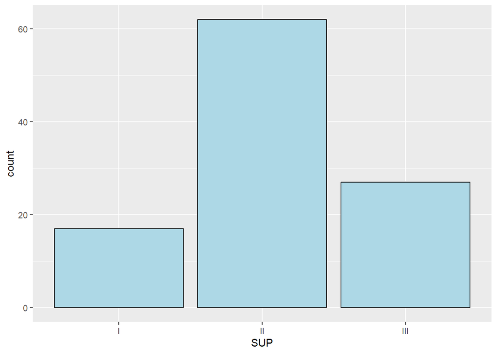

```r
geomorfologia %>%
  ggplot( aes(x=SUP) ) +
  geom_bar(color="black", fill="lightblue")
```

Podemos mapear a superfície geomófica associando `SUP` à estética `fill`:

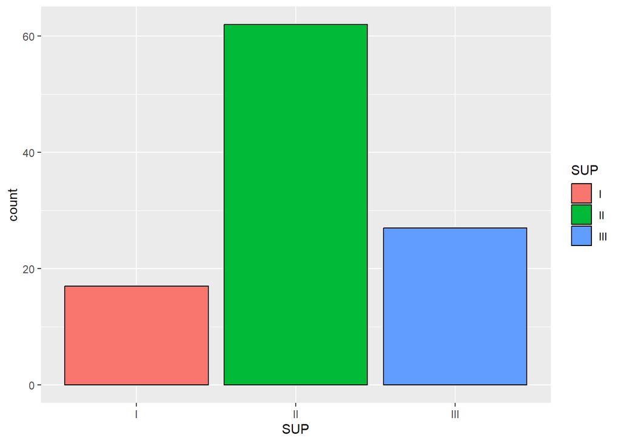

```r
geomorfologia %>%
  ggplot( aes(x=SUP, fill=SUP)) +
  geom_bar(color="black")
```

Se adicionarmos uma segunda variáveis categórica, como o tipo de solo `Solo`, as barras são automaticamente empilhadas, ondem cada retângulo colorido representa uma combinação de `SUP` e `Solo`.

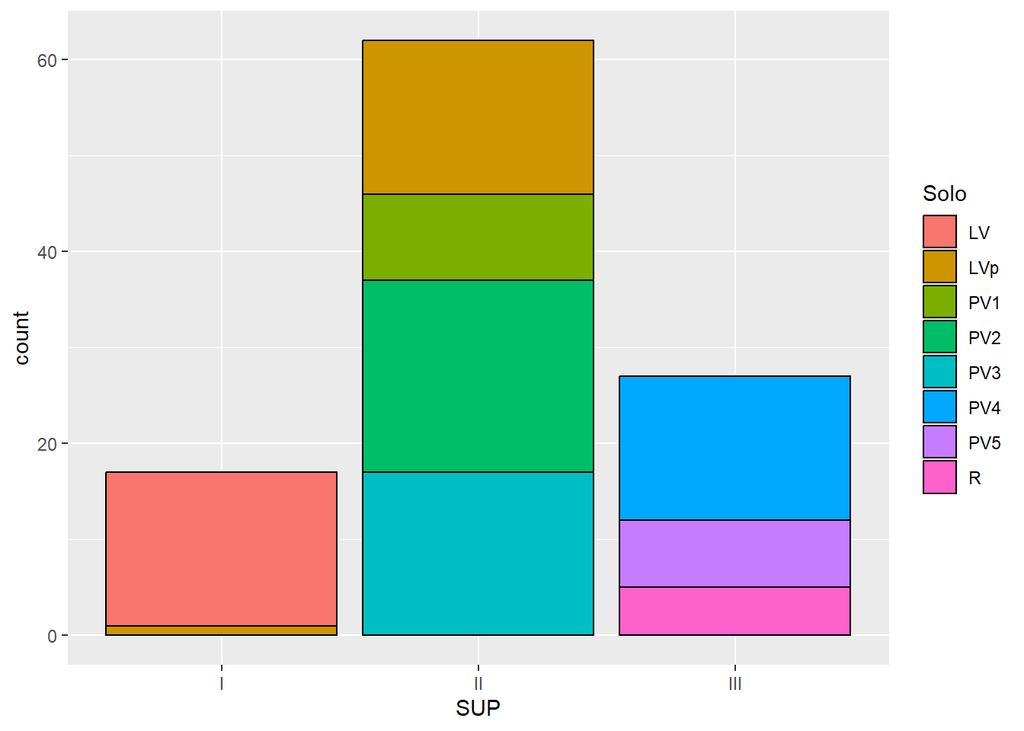

```r
geomorfologia %>%
  ggplot( aes(x=SUP, fill=Solo)) +
  geom_bar(color="black")
```

O empilhamento é realizado automaticamente, caso não queiramos o gráfico empilhado, utilizamos um dos três valores `identity`, `dodge` ou `fill` associados ao argumento `position`.

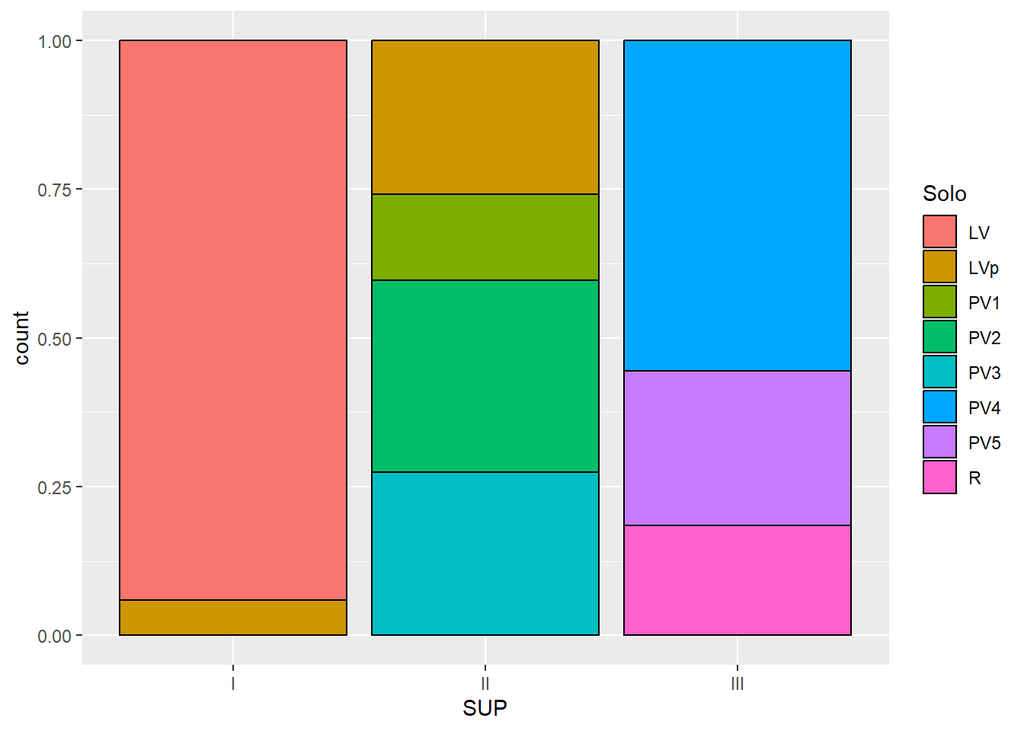

```r
geomorfologia %>%
  ggplot( aes(x=SUP, fill=Solo)) +
  geom_bar(position = "fill", color="black")
```

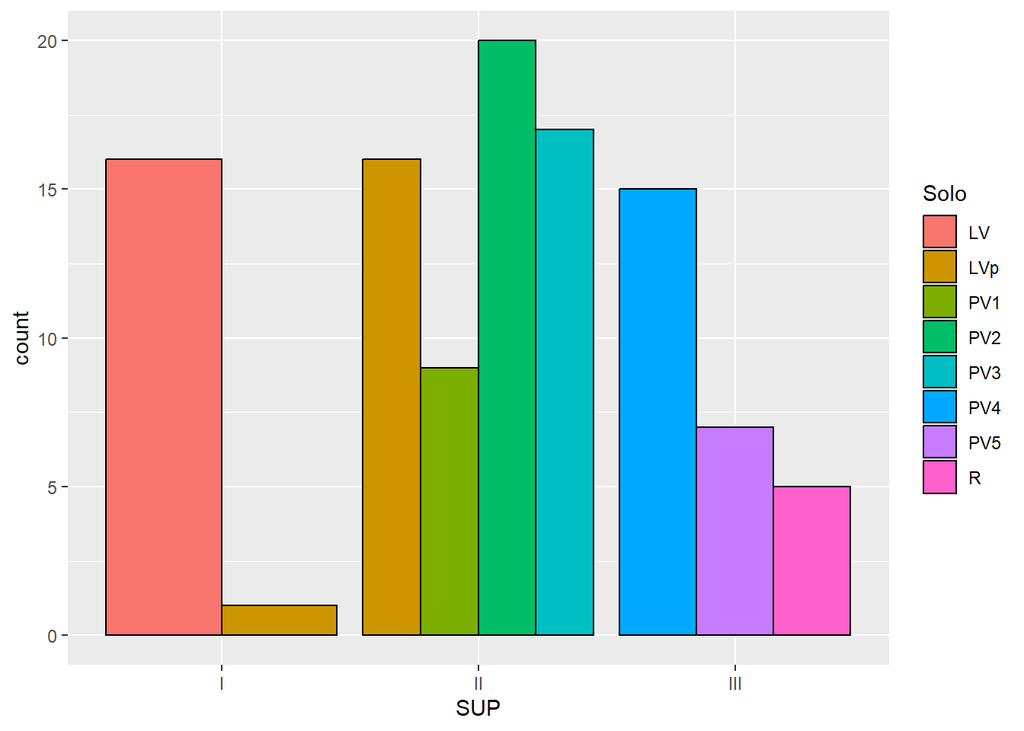

```r
geomorfologia %>%
  ggplot( aes(x=SUP, fill=Solo)) +
  geom_bar(position = "dodge", color="black")
```

### Smoothers

Vamos ajustar uma linha suave aos dados de teor de argila ao longo do transecto X a partir da função `geom_smooth()`.

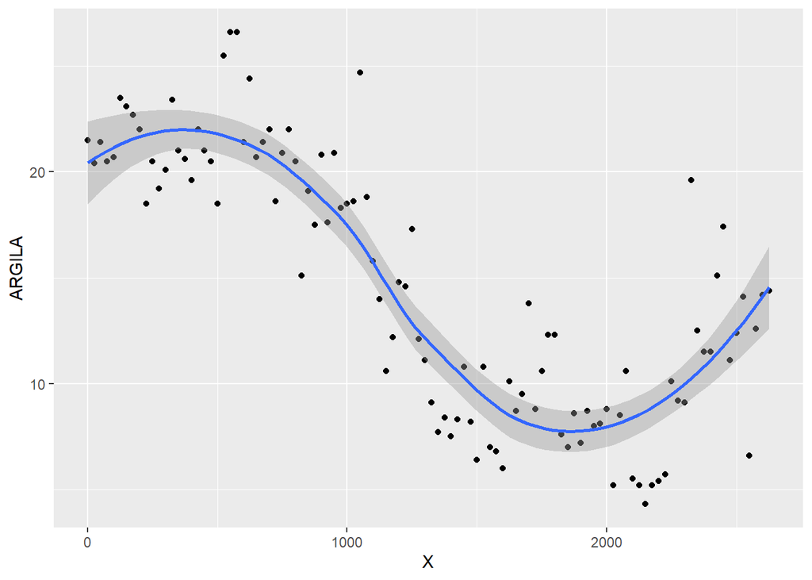

```r
geomorfologia %>%
  ggplot( aes(x=X, y =ARGILA) ) +
  geom_point() +
  geom_smooth()
```

Dentro de `geom_smooth()` podemos controlar o tipo da linha e a cor da linha a partir de `linetype` e `color`, respectivamente.

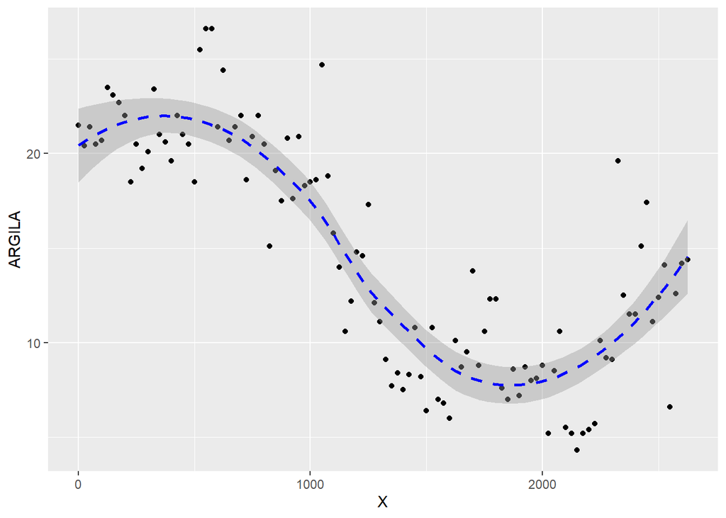

```r
geomorfologia %>%
  ggplot( aes(x=X, y =ARGILA) ) +
  geom_point() +
  geom_smooth(linetype=2, color="blue")
```

Agora vamos aplicar uma linha suave para cada uma das superfícies geomórficas.

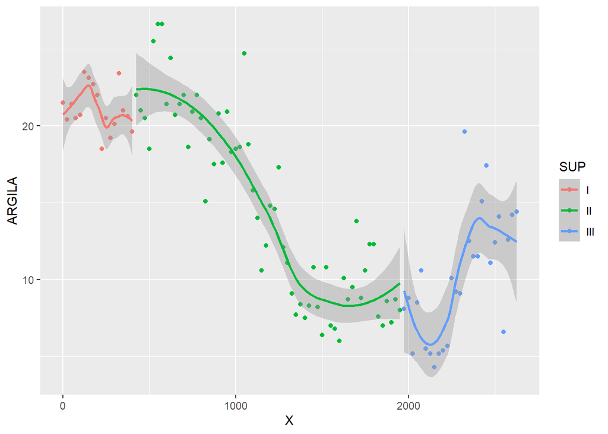

```r
geomorfologia %>%
  ggplot( aes(x=X, y =ARGILA, color=SUP) ) +
  geom_point() +
  geom_smooth()
```

Agora em diferentes facetas.

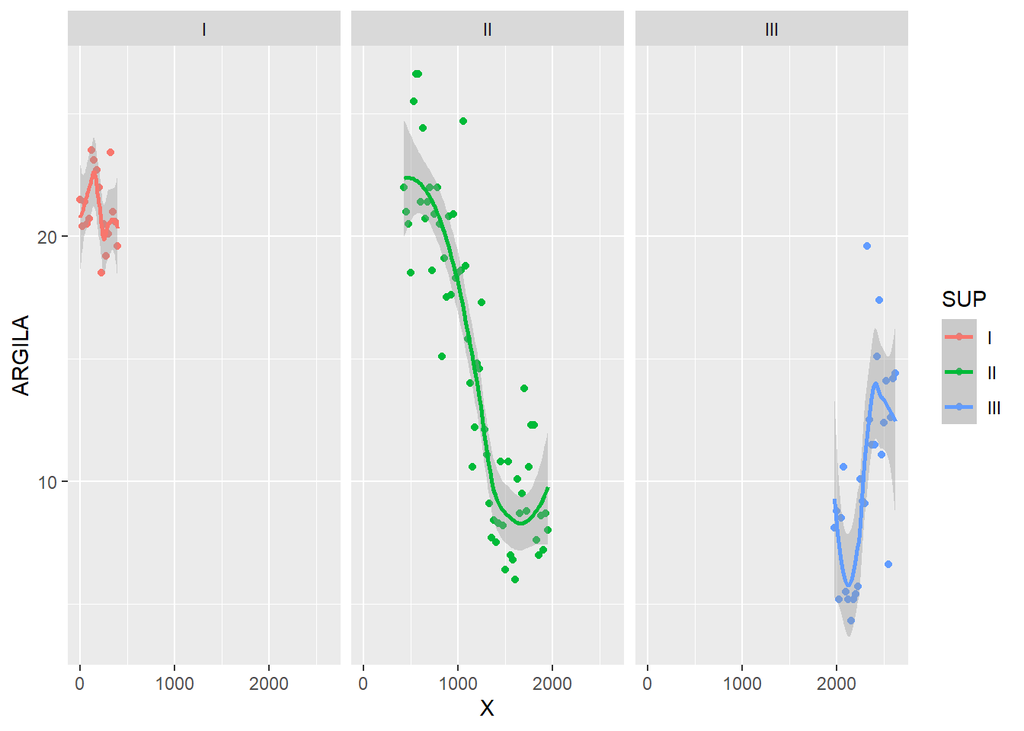

```r
geomorfologia %>%
  ggplot( aes(x=X, y =ARGILA, color=SUP) ) +
  geom_point() +
  geom_smooth() +
  facet_wrap(~SUP, nrow=1)
```

Para apresentarmos as facetas em diferentes escalas (diferentes valores de X e Y em cada faceta), utilize o argumento `scales = "free"` em `facet_wrap()`.

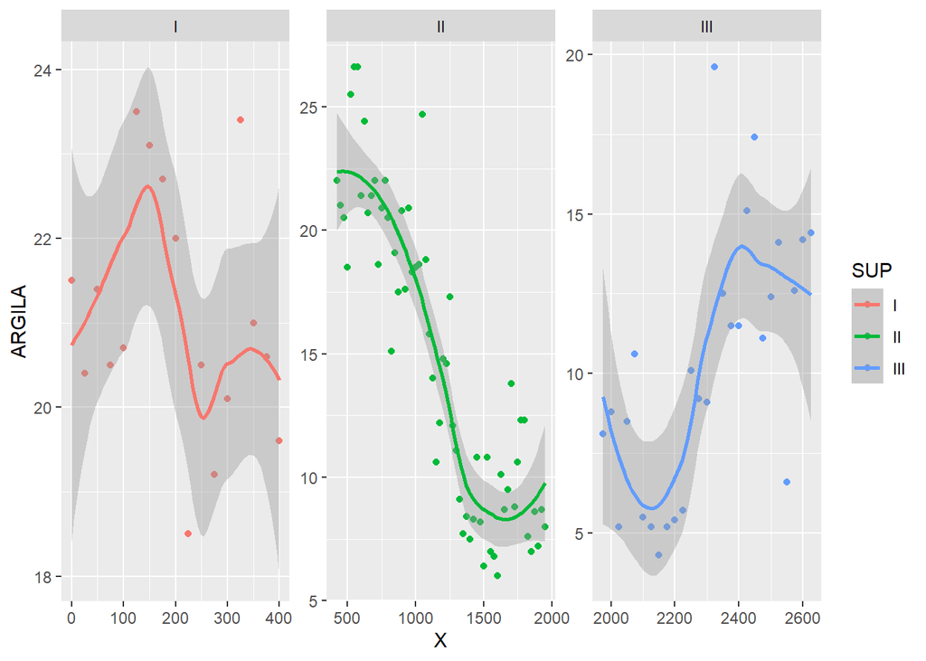

```r
geomorfologia %>%
  ggplot( aes(x=X, y =ARGILA, color=SUP) ) +
  geom_point() +
  geom_smooth() +
  facet_wrap(~SUP, nrow=1, scales = "free")
```

### Boxplot

Conhecido como gráfico dos 5 números representa um resumos dos valores mínimo, primeiro quartil, mediana, terceiro quartil e máximo. Podem ser construídos para uma variável contínua a partir da geometria `geom_boxplot()`. Observe que dentro da função `ggplot()` não é necessário especificar o `y`, somente é atribuído a `x` a variável contínua `ARGILA`.

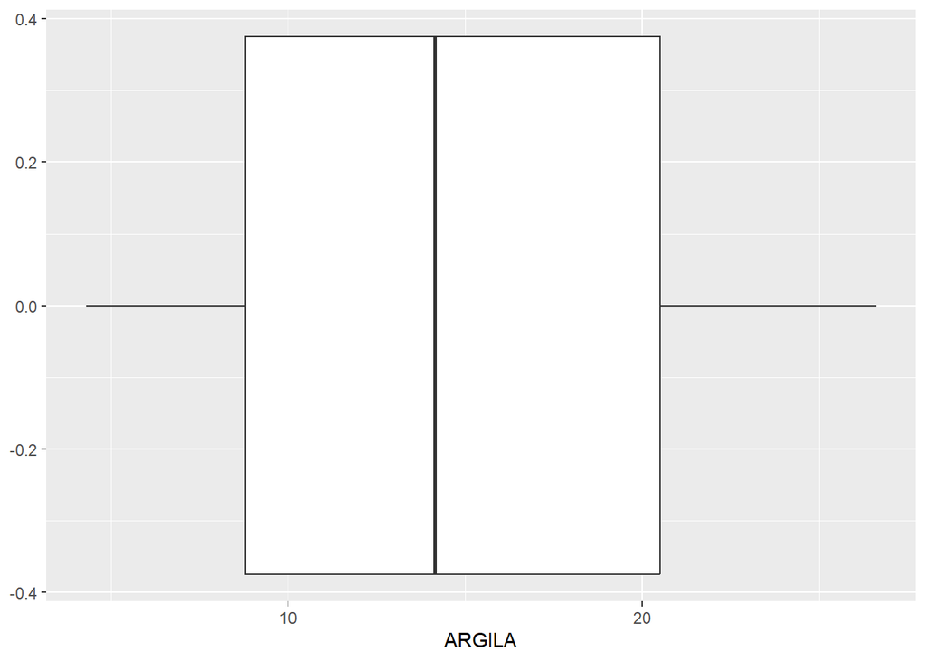

```r
geomorfologia %>%
  ggplot( aes(x=ARGILA) ) +
  geom_boxplot()
```

- O boxplot é uma caixa que vai do 25º percentil ao 75º percentil da distribuição, uma distância conhecida como a amplitude interquartil (IIQ). No meio da caixa há uma linha que exibe a mediana, isto é, 50º percentil, da distribuição. Essas três linhas lhe dão um sentido da dispersão da distribuição e se ela é ou não simétrica sobre a mediana ou enviesada para um lado.
- Pontos visuais que exibem observações que caem mais do que 1,5 vez o IIQ de cada limite da caixa. Esses pontos foram da curva são incomuns, entãosão plotados individuaalmente.
- Uma linha (ou bigode de gato, dai o nome *Box and Whiskers*) que se estende de cada lado da caixa e vai até o ponto mais distante da distribuição que não seja um outlier.

Podemos modificar a orientação do boxplot por meio de `aes(y=ARGILA)`.

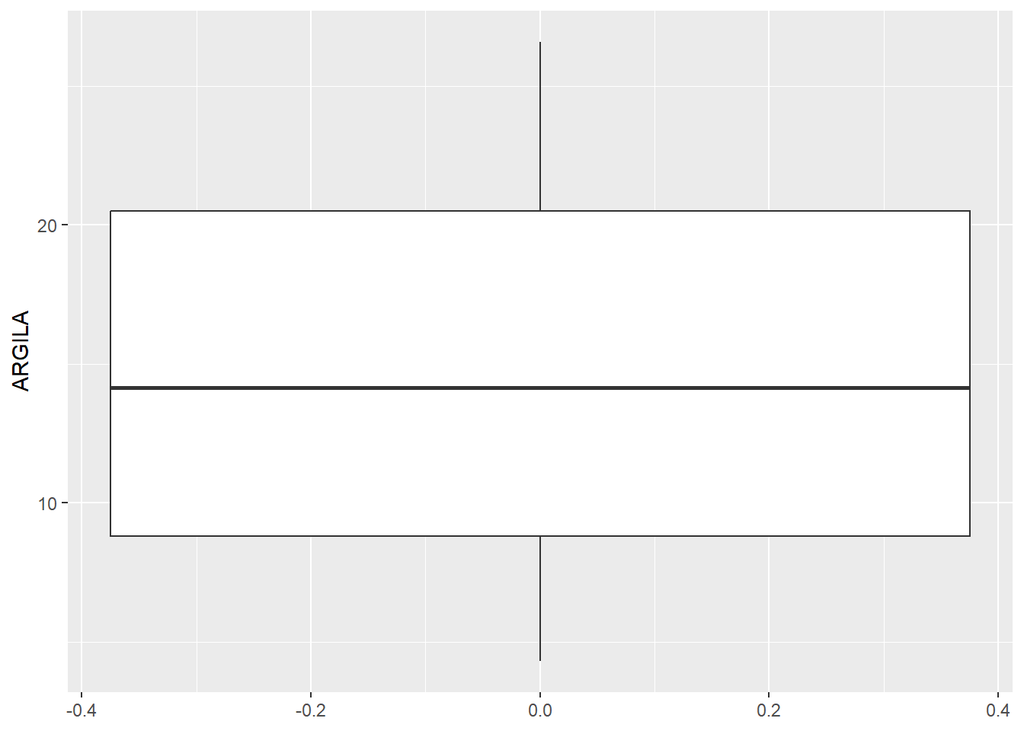

```r
geomorfologia %>%
  ggplot( aes(y=ARGILA) ) +
  geom_boxplot()
```

Outra possibilida é diminuir o tamanho da caixa com `coord_cartesian()`.

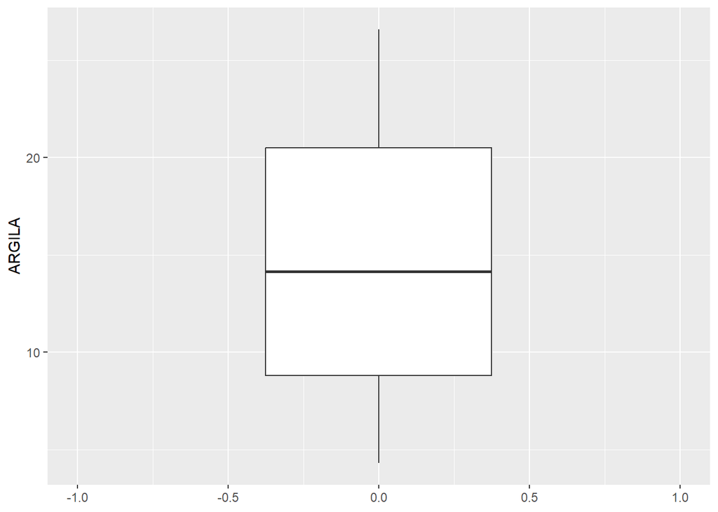

```r
geomorfologia %>%
  ggplot( aes(y=ARGILA) ) +
  geom_boxplot() +
  coord_cartesian(xlim=c(-1,1))
```

Outra alternativa para exibir a distribuição de uma variável contínua é desmembrá-la por uma variável categórica no boxplot.

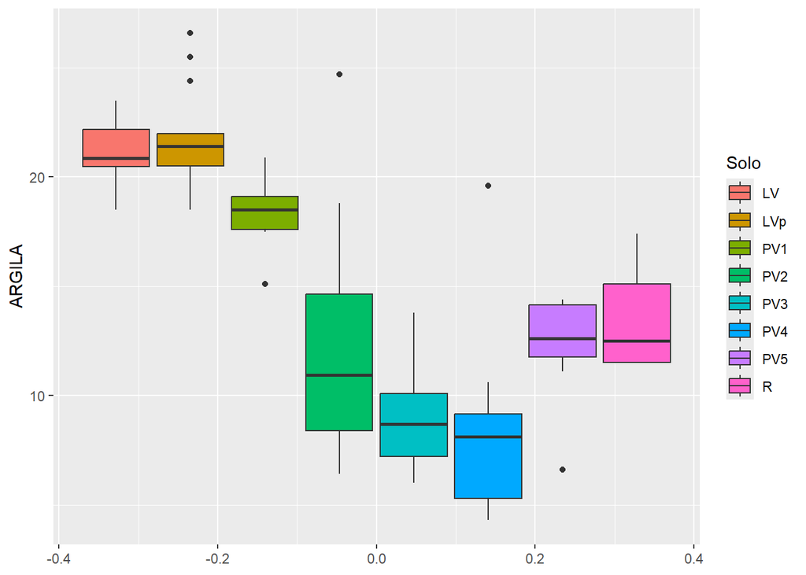

```r
geomorfologia %>%
  ggplot( aes(y=ARGILA, fill=Solo) ) +
  geom_boxplot()
```

### Histograma

O gráfico histograma é facilmente construído a partir da função `geom_histogram()`. Semelhante ao `geom_boxplot()` dentro da função `ggplot()` é atribuído a `x` a variável contínua `ARGILA`.

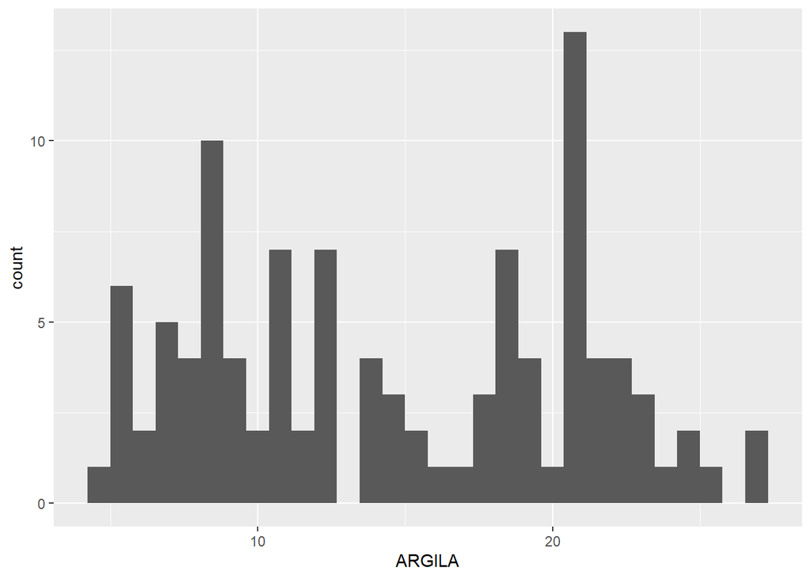

```r
geomorfologia %>%
  ggplot(aes(x=ARGILA)) +
  geom_histogram()
```

Observe que o histograma foi construído com a frequencia absoluta de cada classe, ou seja, o número de observações (contagem) dentro de cada classe de teor de argila construída automaticamentem pela função. Se ao invés da contagem, quiséssemos a densidade de frenquência, deveremos utilizar `y=..density..` dentro de `aes()`.

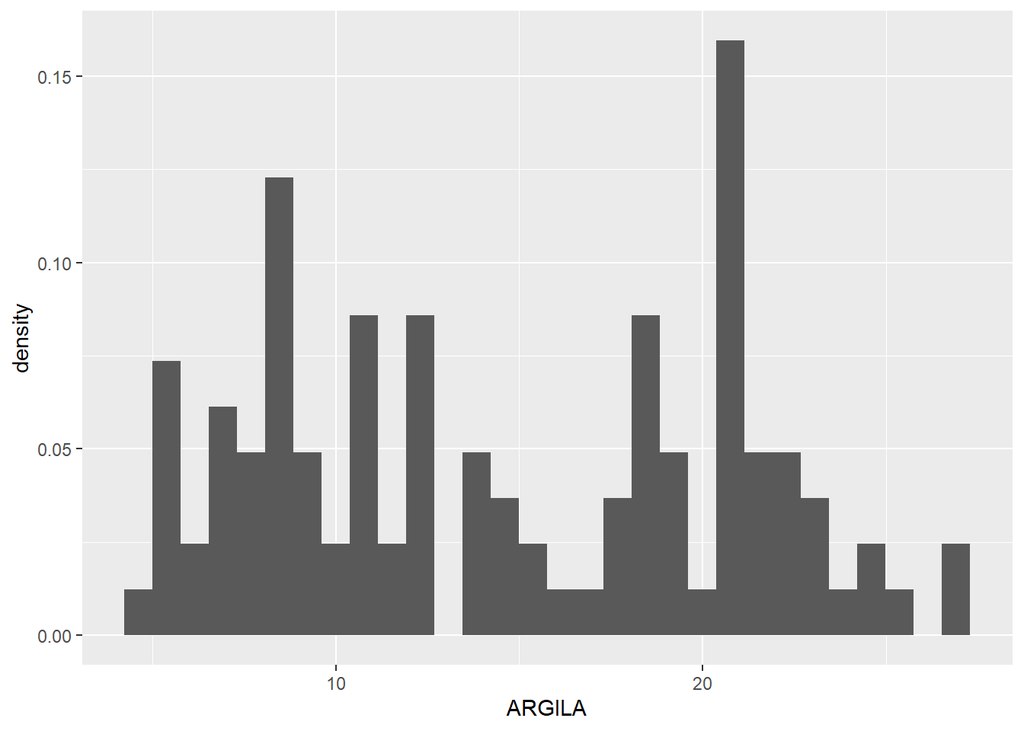

```r
geomorfologia %>%
  ggplot(aes(x=ARGILA, y=..density..)) +
  geom_histogram()
```

Podemos estabelecer a amplitude dos intervalos em um histograma com o argumento `bidwidth`, que é medido nas unidades da variável x.

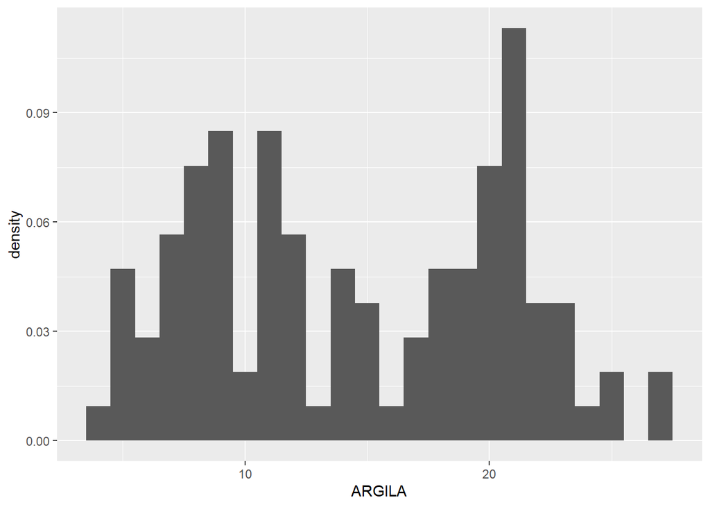

```r
geomorfologia %>%
  ggplot(aes(x=ARGILA, y=..density..)) +
  geom_histogram(binwidth = 1)
```

Ou você pode especificar o número de classes a partir do argumento `bins`, que por default é igual a `30`.

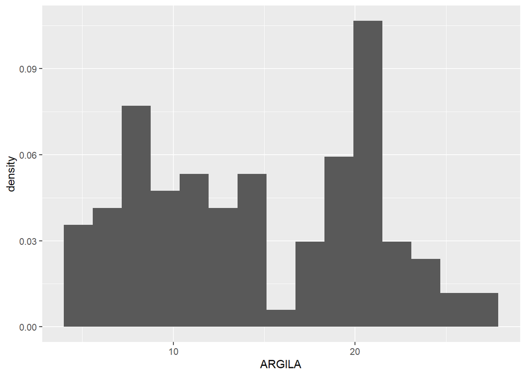

```r
geomorfologia %>%
  ggplot(aes(x=ARGILA, y=..density..)) +
  geom_histogram(bins =  15)
```

Vamos alterar as cores das bordas e do preeenchimento das colunas do histograma.

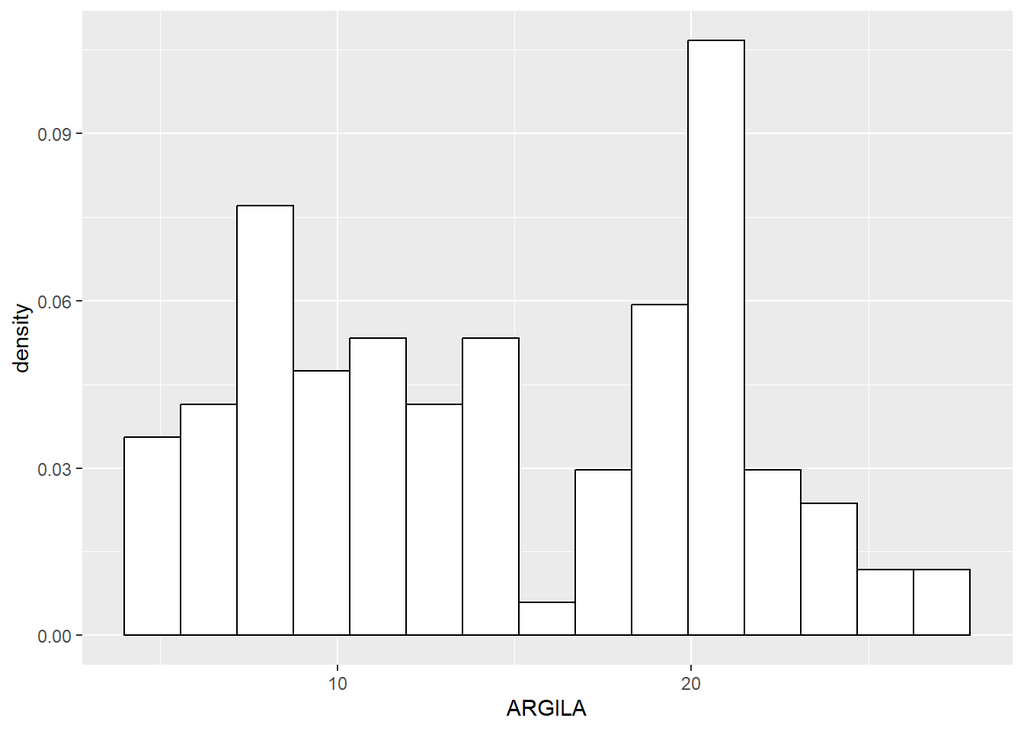

```r
geomorfologia %>%
  ggplot(aes(x=ARGILA, y=..density..)) +
  geom_histogram(bins =  15, color="black",fill="white")
```

Podemos associar a curva suave de densidade no hitograma, a partir da função `geom_density()` e controlar a transparência e seu preenchimento a partir dos argumentos `alpha` e `fill`, respectivamente.

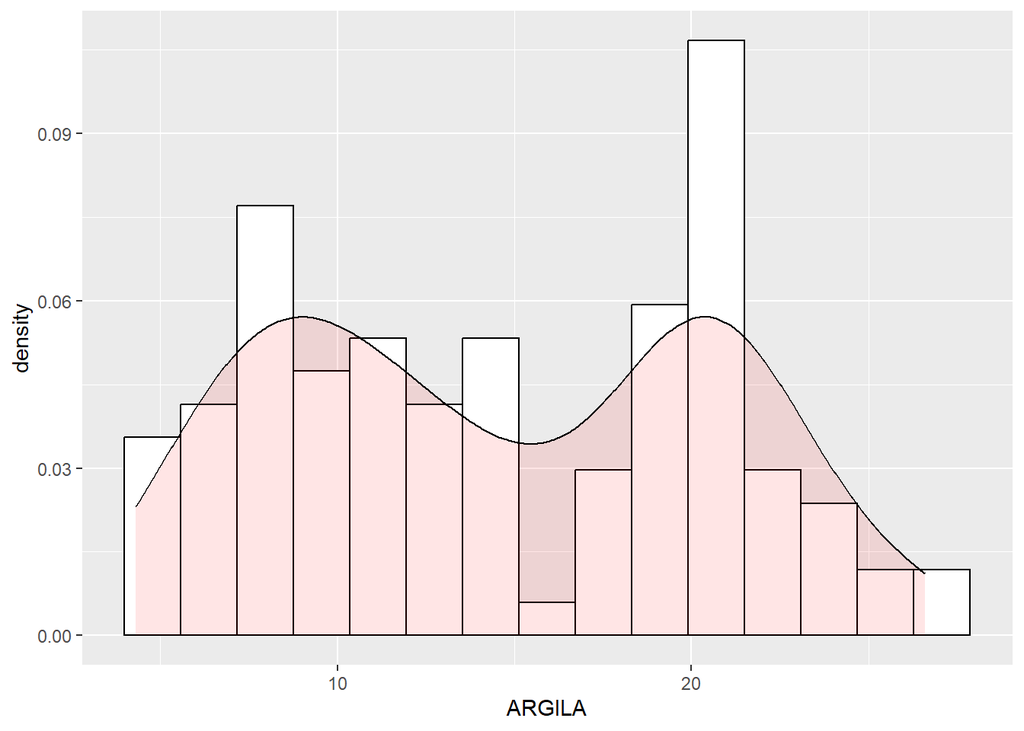

```r
geomorfologia %>%
  ggplot(aes(x=ARGILA, y=..density..)) +
  geom_histogram(bins =  15,color="black",fill="white")+
  geom_density(alpha=.10, fill="red")
```

Finalmente, podemos construir um histograma da variável `ARGILA` para cada superfície geomórfica.

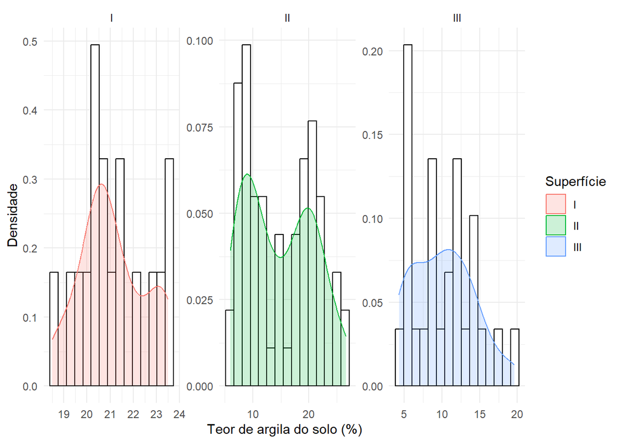

```r
geomorfologia %>%
  ggplot(aes(x=ARGILA, y=..density.., color=SUP, fill=SUP)) +
  geom_histogram(bins =  15, color="black",fill="white")+
  geom_density(alpha=.2)+
  facet_wrap(~SUP, scales="free")+
  labs(x="Teor de argila do solo (%)", y = "Densidade", fill="Superfície", color="Superfície") +
  theme_minimal()
```